# Module 9: Models for continuous time series

## Learning outcomes

- Understand the differences between continuous and discrete time series
- Understand the basics of Brownian motion
- Extend the AR model to the Ornstein-Uhlenbeck process
- Ito formulation vs Euler-Maruyama methods
- Forecasting and interpolation for continuous time models
- Fit different types of change point models

Relevant JAGS file:

```
jags_autoregressive.R
jags_BM.R
jags_OU.R
jags_changepoint.R
```

## Discrete time vs continuous time

- Almost all of the models we have studied so far assume that time is discrete, e.g. \(t=1, 2, 3, \ldots\), or year = \(1850, 1851, \ldots\).
- Many real world time series do not work on discrete times scales. Instead the time value \(t\) might be any integer or non-integer value.
- Continuous time series might occur because:
1. The data are recorded in irregular time, e.g. the ice core data
2. The data contain many missing values. We could use the `NA` trick but if there are too many this becomes impractical
- Really all time series are recorded in continuous time, we just sometimes approximate them onto a grid. There can be lots of subtle issues when data are aggregated incorrectly

## Some models for continuous time we have already met

We have actually already met quite a few methods which work for data recorded in continuous time:

1. Linear and logistic regression
2. Fourier Methods
3. Gaussian processes

However for all of these it could be argued that they are not true time series models since they borrow predictive strength from both the future and the past

## Brownian motion

- Perhaps the simplest of all continuous time series models is that of *Brownian Motion* (BM)
- As we are now working in continuous time we write the time series as \(y(t)\) rather than \(y_t\) to allow for \(y\) to be a function of continuous \(t\)
- The likelihood for BM is:\[y(t) - y(t - s) \sim N(0, s \sigma^2)\]where \(s\) is any positive value. Note that if \(s\) is 1 we have the standard random walk model
- You can also add in a *drift* parameter and re-write the model as:\[y(t) - y(t - s) \sim N(\alpha s, s \sigma^2)\]

## JAGS code for simple Brownian Motion

```r
model_code = '
model
{
  # Likelihood
  for (i in 2:T) {
  y[i] ~ dnorm( alpha * (t[i] - t[i-1]) + y[i-1], tau[i] )
  tau[i] <- 1/( pow(sigma,2) * (t[i] - t[i-1]) )
  }

  # Priors
  alpha ~ dnorm(0.0,0.01)
  sigma ~ dunif(0.0,10.0)
}
'
```

- You can alternatively write this in terms of differences of \(y\) and \(t\)

## Example: ice core data

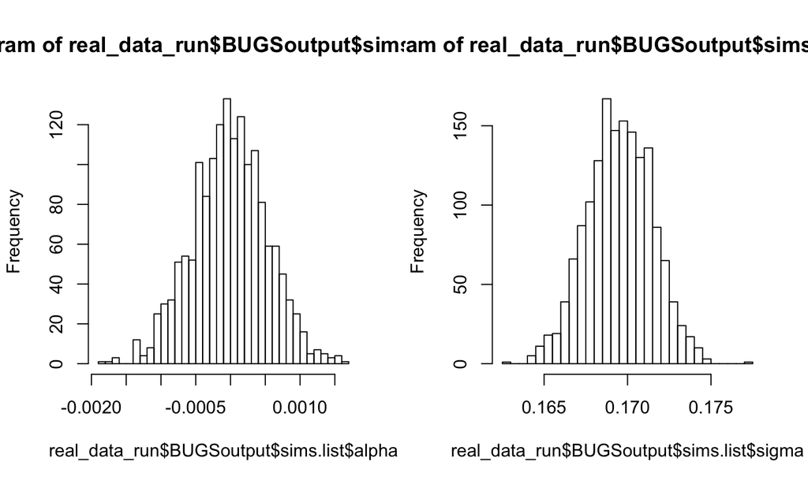

```r
par(mfrow=c(1,2))
hist(real_data_run$BUGSoutput$sims.list$alpha, breaks=30)
hist(real_data_run$BUGSoutput$sims.list$sigma, breaks=30)
```

## Interpolation

- We can use the NA trick to create a new set of times at which we wish to predict \(\delta^{18}\)O
- We need to be careful that we don't give JAGS any time values which have 0 differences as this will cause it to crash

```r
t_ideal = seq(0+0.01,max(ice$Age)+0.01, by = 100) # 100 year regular grid
# Note added on 0.01 to the above to stop there being some zero time differences
y_ideal = rep(NA, length(t_ideal))
t_all = c(ice$Age, t_ideal)
y_all = c(ice$Del.18O, y_ideal)
o = order (t_all)
t_all[o][1:10]
```

```
##  [1] -20.00   0.00   0.01  20.00  40.00  60.00  80.00 100.00 100.01 120.00
```

```r
y_all[o][1:10]
```

```
##  [1] -34.70 -34.78     NA -34.84 -35.16 -35.18 -34.72 -35.28     NA -35.28
```

## Interpolation plots

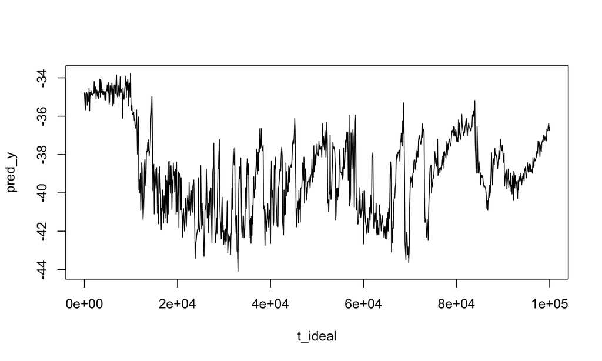

```r
pick_out = which( is.na(real_data_2$y) )
pred_y = apply(real_data_run_2$BUGSoutput$sims.list$y[, pick_out], 2, 'mean')
plot(t_ideal, pred_y, type = 'l')
```

## The Ornstein Uhlenbeck process

- One extension of Brownian Motion is called the *Ornstein-Uhlenbeck* (OU) process
- It can also be thought of as the continuous time version of the AR(1) process
- The likelihood is:\[y(t) - y(t-s) \sim N( \theta ( \alpha - y(t-s) ) s, s \sigma^2 )\]
- It looks very much like the BM model but with an extra parameter \(\theta\) which controls the dependence of \(y(t)\) on \(y(t-s)\) according to how far away it is
- With a bit of algebra if you set \(s=1\) above you end up with the AR(1) model
- Like the AR(1) model, \(\theta\) needs to be between -1 and 1 to be stationary, but in practice can go beyond that range

## JAGS code for the OU process

```r
model_code = '
model
{
  # Likelihood
  for (i in 2:T) {
    y[i] ~ dnorm( theta * (alpha - y[i-1]) * (t[i] - t[i-1]) + y[i-1], tau[i] )
    tau[i] <- 1/( pow(sigma,2) * (t[i] - t[i-1]) )
  }

  # Priors
  alpha ~ dnorm(0, 0.01)
  theta ~ dunif(0, 100)
  sigma ~ dunif(0.0, 10.0)
}
'
```

## Example: Monticchio palaeo data

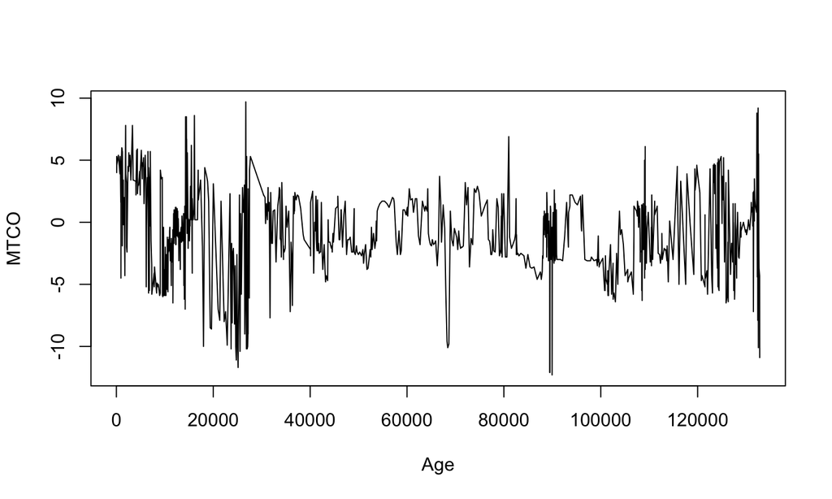

```r
mont = read.csv('https://raw.githubusercontent.com/andrewcparnell/tsme_course/master/data/Monticchio_MTCO.csv')
with(mont, plot(Age, MTCO, type='l'))
```

## Monticchio output

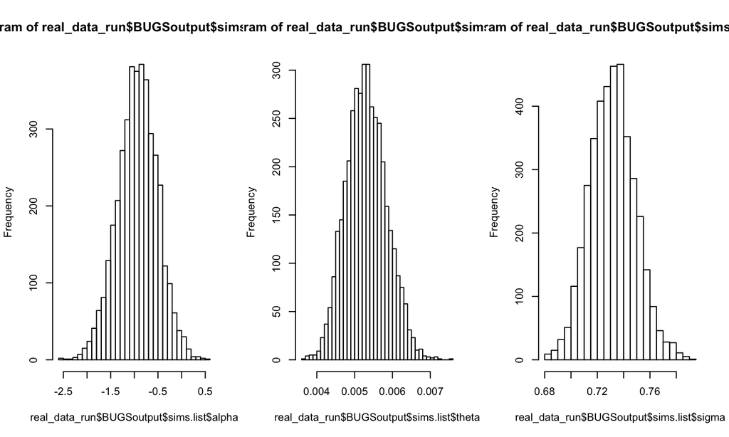

```r
par(mfrow=c(1,3))
hist(real_data_run$BUGSoutput$sims.list$alpha, breaks=30)
hist(real_data_run$BUGSoutput$sims.list$theta, breaks=30)
hist(real_data_run$BUGSoutput$sims.list$sigma, breaks=30)
```

## Ito vs Euler-Marayuma forms

- You will often see, e.g. the BM model written as:\[dy = \alpha dt + \sigma dW(t)\]
- This is sometimes called *Ito* form and is a stochastic differential equation with \(W\) a standard BM (i.e. with unit variance 1 and no drift)
- An alternative is to discretise the equation in *Euler-Marayama* form:\[y(t) - y(t-s) = \alpha s + \sigma ( W(t) - W(t-s) )\]
- Writing it in this form makes it easier to see the likelihood version we used:\[y(t) - y(t - s) \sim N(\alpha s, s \sigma^2)\]
- The Ito format for the OU process is:\[dy = \theta ( \alpha - y ) dt + \sigma dW(t)\]

## Introduction to change point models

- Another method commonly used for both discrete and continuous time stochastic processes is that of change point modelling
- The goal is to find one or more *change points*; times at which the time series changes in some structural way
- We will study two versions of change point models; *discontinuous*, where there can be instantaneous jumps in the mean, and *continuous* where there can be a jump in the rate of change of the mean, but subsections must link together

## Dscontinuous change point regression models

- We will write the overall model as:\[y(t) \sim N(\mu(t), \sigma^2)\]
- For the discontinuous change point regression (DCPR) model with one change point\[\mu(t) = \left\{ \begin{array}{ll} \alpha_1 & \mbox{ if } t < t_1 \\ \alpha_2 & \mbox{ if } t \ge t_1 \end{array} \right.\]
- Here, \(\alpha_1\) and \(\alpha_2\) are the mean before and after the change point respectively, and \(t_1\) is a parameter which gives the time of the change in the mean
- In JAGS we use the `step` function to determine which side of the change point a data point is currently on

## JAGS code

```r
model_code_DCPR_1="
model
{
  # Likelihood
  for(i in 1:T) {
    y[i] ~ dnorm(mu[i], tau)
    mu[i] <- alpha[J[i]]
    # This is the clever bit - only pick out the right change point when above t_1
    J[i] <- 1 + step(t[i] - t_1)
  }

  # Priors
  alpha[1] ~ dnorm(0.0, 0.01)
  alpha[2] ~ dnorm(0.0, 0.01)
  t_1 ~ dunif(t_min, t_max)

  tau <- 1/pow(sigma, 2)
  sigma ~ dunif(0, 100)
}
"
```

## Continuous change point regression models

- The continuous change point regression model (CCPR) forces the segments to join together
- The mean for this version is:\[\mu(t) = \left\{ \begin{array}{ll} \alpha + \beta_1 (t - t_1) & \mbox{ if } t < t_1 \\ \alpha + \beta_2 (t - t_1) & \mbox{ if } t \ge t_1 \end{array} \right.\]
- In this version \(\beta_1\) and \(\beta_2\) are the rates of change before and after the change point, \(\alpha\) is the mean value of \(y\) at the change point
- Code for multiple change point models is given in the R code `jags_changepoint.R`. We can compare between them using DIC

## JAGS code for CCPR

```r
model_code_CCPR_1="
model
{
  # Likelihood
  for(i in 1:T) {
    y[i] ~ dnorm(mu[i], tau)
    mu[i] <- alpha + beta[J[i]]*(t[i]-t_1)
    # This is the clever bit - only pick out the right change point when above t_1
    J[i] <- 1 + step(t[i] - t_1)
  }

  # Priors
  alpha ~ dnorm(0.0, 0.01)
  beta[1] ~ dnorm(0.0, 0.01)
  beta[2] ~ dnorm(0.0, 0.01)
  t_1 ~ dunif(t_min, t_max)

  tau <- 1/pow(sigma, 2)
  sigma ~ dunif(0, 100)
}
"
```

## Example: change points of global temperature

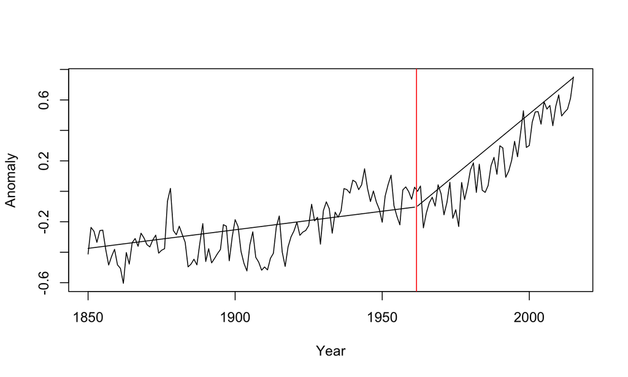

## Summary

- We have covered some methods for continuous time series including Brownian Motion and Ornstein-Uhlenbeck
- These are extensions of some of the discrete time methods we have already met, such as the random walk and the AR(1) process
- We have looked at how these models can be written out in Ito and Euler-Marayama format
- We have covered discontinuous and continuous change point models, and shown how they apply to the global temperature series